# Demand and Inventory Planning Utilities

Ken Brooks

November 13, 2015

## Prepare data

Data preparation involves two steps once the import from the csv file is complete: * Making sure that nothing has changed in the formatting of the input data. This is accomplished via the “checkData” function. * Doing base cleanup on data to make sure that dates are formatted correctly, among other things. This is performed via the “cleanImportedData” function.

## checkData(data) function

The “checkData” function is used to verify that the format of an incoming CSV file has not changed from that expected.

Usage: * The function takes a data frame, data, as an input. * It returns nothing, but if a change in format has occurred, it throws an error encouraging the analyst to discover what has changed in the input data structure. * A future enhancement of this function would identify the specific location of the error.

## cleanImportedData(data) function

The “cleanImportedData” function is used to perform base cleanup on imported data to make sure that dates are formatted correctly, among other things.

Usage: * The function takes a data frame, data, as an input. * It returns a data frame with correctly formatted columns for further processing.

```r
checkData(data)  # check that nothing has changed in input format
data <- cleanImportedData(data)  # cleanup imported data
saveRDS(data, "data.rds")
```

## Build data frames

There are two data frames required for further analysis: the title.data data frame and the time.series.data data frame. These two data frames hold title metadata and title historical demand, respectively and are created by the “createTitleDF(data)” and “createTSDF(data)” functions.

## createTitleDF(data) function

The createTitleDF(data) function extracts title metadata from the imported file, normalizes the result and saves the data into a .rds file.

Usage: * The function takes the imported and cleaned data frame from cleanImportedData(data) * It returns a normalized title.data data frame and saves title_data.rds to disk.

## createTSDF(data) function

The createTSDF(data) function extracts title demand data from the imported file, normalizes the result and saves the data into a .rds file. The TSDF in the function name refers to “Time Series Data Frame.”

Usage: * The function takes the imported and cleaned data frame from cleanImportedData(data). * It returns a time.series.data data frame and saves time_series.rds to disk.

```r
# Retrieve stored data
data = readRDS("data.rds")

title.data <- createTitleDF(data)  # create title metadata df
time.series.data <- createTSDF(data)  # create time.series df


saveRDS(title.data, "title_data.rds")
saveRDS(time.series.data, "time_series.rds")
```

## Forecast a single title

The “n.month.forecast” function is used to generate a forecast for a single title. It generates a forecast over the specified horizon for a particular isbn.

Usage: * The function takes an isbn as a string, a time series dataframe (to look up the data), and a specified horizon.  
* It returns a single column dataframe of the forecast, indexed by the date of the forecast. * Examples:

```r
isbn = "0716756676"  # set the ISBN (this can be changed)

time.series.data = readRDS("time_series.rds") # read the time series data

fcst <- n.month.forecast(isbn, time.series.data, 15) # generate the forecast
fcst  # display it
```

```
##            0716756676
## 2015-11-01   61.62641
## 2015-12-01   61.62641
## 2016-01-01   61.62641
## 2016-02-01   61.62641
## 2016-03-01   61.62641
## 2016-04-01   61.62641
## 2016-05-01   61.62641
## 2016-06-01   61.62641
## 2016-07-01   61.62641
## 2016-08-01   61.62641
## 2016-09-01   61.62641
## 2016-10-01   61.62641
## 2016-11-01   61.62641
## 2016-12-01   61.62641
## 2017-01-01   61.62641
```

## Forecast all titles

The “build.forecast.DF” function is used to generate a forecast for all of the titles in a title.data data frame. It uses “n.month.forecast” above, iteratively to generate the forecasts.

Usage: * The function takes a title.data data frame and and time.series.data data frame (see above)  
* It returns a data frame of forecasts along with 3, 6, 9, 12 and 15-month accumulations. * It saves these to both to rds and CSV

Enhancements: * Check the csv for strings in the ISBNs - dropping leading zeros * Replace all negative forecasts with 0 before doing the sum (or do this on the base forecast?)

Examples:

```r
# Get all of the time series and title data
time.series.data = readRDS("time_series.rds")
title.data = readRDS("title_data.rds")

title.forecasts <- build.forecast.DF(title.data, time.series.data)
```

## previous.edition.isbn(isbn, title.df)

This function returns the previous edition’s ISBN.

Usage: * Takes ISBN as a string, and a data frame as an input. * It returns the previous ISBN as a string, or NA if no previous ISBN is available.

```r
title.data = readRDS("title_data.rds")
source("Inv_Planning.R")

isbn1 = "1319056911"  # How Life Works
previous.edition.isbn(isbn1, title.data)
```

```
## [1] "1429218703"
```

```r
isbn2 <- "031243829X"  # Note that this title does not have a previous edition
previous.edition.isbn(isbn2, title.data)  # should fail
```

```
## [1] NA
```

## sum.edition.data(isbn, time.series.data, title.data)

In the event that a title does not have sufficient data to generate a forecast, it might be helpful to add the previous edition’s data to the current edition to provide a longer time series. This function essentially creates a third title by adding the current edition’s data and the previous edition’s data.

Usage: * Takes an ISBN as a string and two data frames: title data and title time series as inputs * Returns a new time series with the summed values from that ISBN and its previous edition. If there is no previous edition, it returns the data from the first edition only.

```r
time.series.data = readRDS("time_series.rds")
title.data = readRDS("title_data.rds")
source("Inv_Planning.R")

isbn1 = "1319056911"  # How Life Works
sum.edition.data(isbn1, time.series.data, title.data)
```

```
##       Jan  Feb  Mar  Apr  May  Jun  Jul  Aug  Sep  Oct  Nov  Dec
## 2012                                                57   30    3
## 2013   45  119   65  488 1059 2799 3460    0  154  781  736   43
## 2014  124  288  143 1210 1566 1161  557   36  356  751  266    3
## 2015   32   24   78   92    2 2586 1110   25  401   12
```

```r
isbn2 <- "031243829X"  # Note that this title does not have a previous edition
sum.edition.data(isbn2, time.series.data, title.data)
```

```
##       Jan  Feb  Mar  Apr  May  Jun  Jul  Aug  Sep  Oct  Nov  Dec
## 1994   NA   NA   NA   NA   NA   NA   NA   NA   NA   NA   NA   NA
## 1995   NA   NA   NA   NA   NA   NA   NA   NA   NA   NA   NA   NA
## 1996   NA   NA   NA   NA   NA   NA   NA   NA   NA   NA   NA   NA
## 1997   NA   NA   NA   NA   NA   NA   NA   NA   NA   NA   NA   NA
## 1998   NA   NA   NA   NA   NA   NA   NA   NA   NA   NA   NA   NA
## 1999   NA   NA   NA   NA   NA   NA   NA   NA   NA   NA   NA   NA
## 2000   NA   NA   NA   NA   NA   NA   NA   NA   NA   NA   NA   NA
## 2001   NA   NA   NA   NA   NA   NA   NA   NA   NA   NA   NA   NA
## 2002   NA   NA   NA   NA   NA   NA   NA   NA   NA   NA   NA   NA
## 2003   NA   NA   NA   NA   NA   NA   NA   NA   NA   NA   NA   NA
## 2004   NA   NA   NA   NA   NA   NA   NA   NA   NA   NA    1   19
## 2005  124   32  970  743 3395 1939  795  454  289 1250  530  358
## 2006  308  128  259  762 1919 2996 1540  218  145 1854  468  666
## 2007  101  169  428  796 1339 2509 1218  320  209 1291  741  313
## 2008  220   73  493  525 2030 1618 1652  679  416  807  386  186
## 2009  174  696  236  658 1050 3772 1402  132  508 1361  417  182
## 2010  262  166  180  403 2667 3317 2690   25  422 2006  731  170
## 2011  271  177  430  619 2445 2874  743  167  982 1001  623  219
## 2012   63  247  550  934 1631 2092  604   44  884  608  231   47
## 2013   81  153   94  121  114  544   11    0    0  315   44    0
## 2014    0   NA   NA    0    0   NA   NA   NA    0   NA   NA   NA
## 2015   NA   NA   NA   NA   NA   NA    0    0    0   NA
```

```r
# which should be the same as the data from the previous edition:
time.series.data[,isbn2]
```

```
##       Jan  Feb  Mar  Apr  May  Jun  Jul  Aug  Sep  Oct  Nov  Dec
## 1994   NA   NA   NA   NA   NA   NA   NA   NA   NA   NA   NA   NA
## 1995   NA   NA   NA   NA   NA   NA   NA   NA   NA   NA   NA   NA
## 1996   NA   NA   NA   NA   NA   NA   NA   NA   NA   NA   NA   NA
## 1997   NA   NA   NA   NA   NA   NA   NA   NA   NA   NA   NA   NA
## 1998   NA   NA   NA   NA   NA   NA   NA   NA   NA   NA   NA   NA
## 1999   NA   NA   NA   NA   NA   NA   NA   NA   NA   NA   NA   NA
## 2000   NA   NA   NA   NA   NA   NA   NA   NA   NA   NA   NA   NA
## 2001   NA   NA   NA   NA   NA   NA   NA   NA   NA   NA   NA   NA
## 2002   NA   NA   NA   NA   NA   NA   NA   NA   NA   NA   NA   NA
## 2003   NA   NA   NA   NA   NA   NA   NA   NA   NA   NA   NA   NA
## 2004   NA   NA   NA   NA   NA   NA   NA   NA   NA   NA    1   19
## 2005  124   32  970  743 3395 1939  795  454  289 1250  530  358
## 2006  308  128  259  762 1919 2996 1540  218  145 1854  468  666
## 2007  101  169  428  796 1339 2509 1218  320  209 1291  741  313
## 2008  220   73  493  525 2030 1618 1652  679  416  807  386  186
## 2009  174  696  236  658 1050 3772 1402  132  508 1361  417  182
## 2010  262  166  180  403 2667 3317 2690   25  422 2006  731  170
## 2011  271  177  430  619 2445 2874  743  167  982 1001  623  219
## 2012   63  247  550  934 1631 2092  604   44  884  608  231   47
## 2013   81  153   94  121  114  544   11    0    0  315   44    0
## 2014    0   NA   NA    0    0   NA   NA   NA    0   NA   NA   NA
## 2015   NA   NA   NA   NA   NA   NA    0    0    0   NA
```

## align.previous.edition(isbn, time.series.data, title.data)

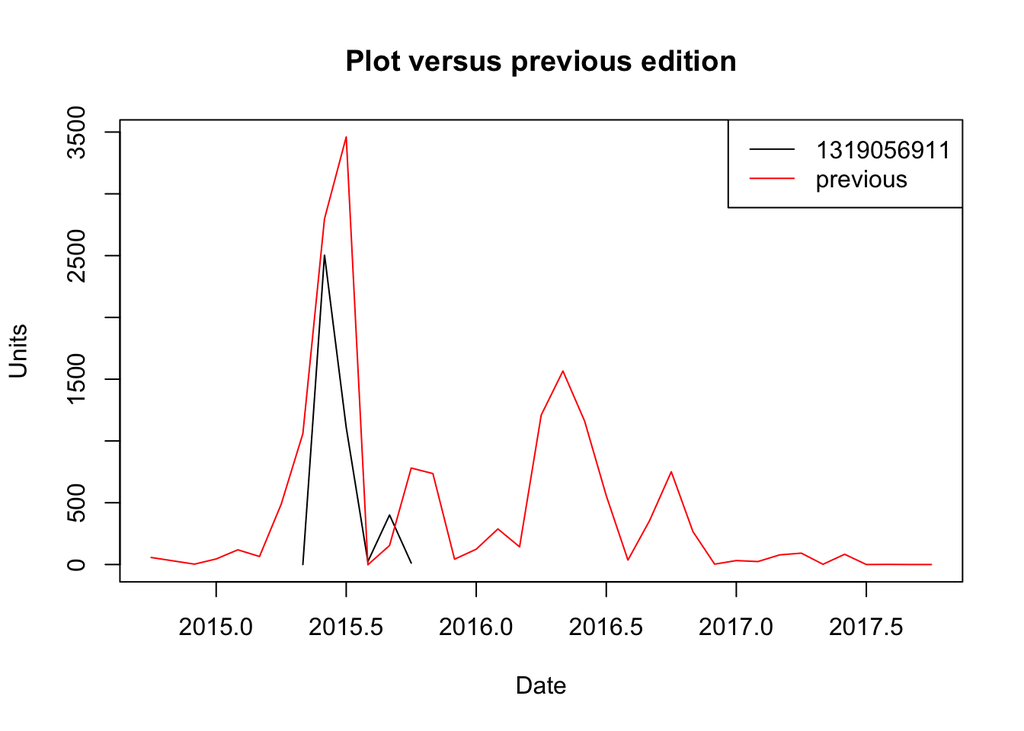

```
##       Jan  Feb  Mar  Apr  May  Jun  Jul  Aug  Sep  Oct  Nov  Dec
## 1994   NA   NA   NA   NA   NA   NA   NA   NA   NA   NA   NA   NA
## 1995   NA   NA   NA   NA   NA   NA   NA   NA   NA   NA   NA   NA
## 1996   NA   NA   NA   NA   NA   NA   NA   NA   NA   NA   NA   NA
## 1997   NA   NA   NA   NA   NA   NA   NA   NA   NA   NA   NA   NA
## 1998   NA   NA   NA   NA   NA   NA   NA   NA   NA   NA   NA   NA
## 1999   NA   NA   NA   NA   NA   NA   NA   NA   NA   NA   NA   NA
## 2000   NA   NA   NA   NA   NA   NA   NA   NA   NA   NA   NA   NA
## 2001   NA   NA   NA   NA   NA   NA   NA   NA   NA   NA   NA   NA
## 2002   NA   NA   NA   NA   NA   NA   NA   NA   NA   NA   NA   NA
## 2003   NA   NA   NA   NA   NA   NA   NA   NA   NA   NA   NA   NA
## 2004   NA   NA   NA   NA   NA   NA   NA   NA   NA   NA   NA   NA
## 2005   NA   NA   NA   NA   NA   NA   NA   NA   NA   NA   NA   NA
## 2006   NA   NA   NA   NA   NA   NA   NA   NA   NA   NA   NA   NA
## 2007   NA   NA   NA   NA   NA   NA   NA   NA   NA   NA   NA   NA
```

[output cut: 34 more lines]

```r
time.series.data = readRDS("time_series.rds")
title.data = readRDS("title_data.rds")
source("Inv_Planning.R")

isbn1 = "1319056911"  # How Life Works
align.previous.edition(isbn1, time.series.data, title.data)
```

```r
isbn3 <- "031243829X"  # Note that this title does not have a previous edition
align.previous.edition(isbn3, time.series.data, title.data)  # should fail
```

```
## [1] NA
```

## forecast.zeros(ts, horizon)

This function takes a time series and a horizon and returns a 0 forecast over that horizon.

Usage: * Input: a time series * Output: a time-indexed data frame with zero values over the forecast period

```r
rm(list = ls())
time.series.data = readRDS("time_series.rds")
title.data = readRDS("title_data.rds")
source("Inv_Planning.R")

isbn1 = "1319056911"  # How Life Works
ts = time.series.data[,isbn1] # get the time series for this title
fcst = forecast.zeros(ts, 15)
fcst
```

```
##            zeros
## 2015-11-01     0
## 2015-12-01     0
## 2016-01-01     0
## 2016-02-01     0
## 2016-03-01     0
## 2016-04-01     0
## 2016-05-01     0
## 2016-06-01     0
## 2016-07-01     0
## 2016-08-01     0
## 2016-09-01     0
## 2016-10-01     0
## 2016-11-01     0
## 2016-12-01     0
## 2017-01-01     0
```

## output.multiple(isbn, time.series.data, title.data)

Generates multiple forecast variants based on the amount of information available for title demand. Among the forecasts considered are: * An n.month.forecast() * A forecast based on sum.edition.data() * Data from the previous edition shifted to be the forecast for the current edition from align.previous.edition() * forecast.zeros() in the event that nothing works

Usage * The function takes an ISBN (as a string) and time.series.data and title.data data frames * The function returns a datafram of all relevant forecasts and saves a CSV file (isbn.csv), with the same information for inspection and usage

```r
rm(list = ls())
# Get all of the time series and title data
time.series.data = readRDS("time_series.rds")
title.data = readRDS("title_data.rds")
source("Inv_Planning.R")

isbn = "1319056911"  # How Life Works

isbn.out = output.multiple(isbn, time.series.data, title.data)
```

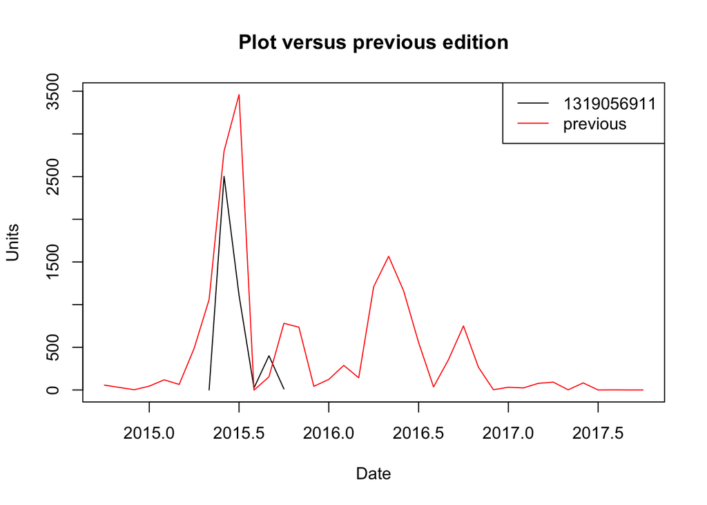

```r
isbn.out
```

```
##            zeros   summed prev act
## 2015-11-01     0 558.5919      736
## 2015-12-01     0 558.5919       43
## 2016-01-01     0 558.5919      124
## 2016-02-01     0 558.5919      288
## 2016-03-01     0 558.5919      143
## 2016-04-01     0 558.5919     1210
## 2016-05-01     0 558.5919     1566
## 2016-06-01     0 558.5919     1161
## 2016-07-01     0 558.5919      557
## 2016-08-01     0 558.5919       36
## 2016-09-01     0 558.5919      356
## 2016-10-01     0 558.5919      751
## 2016-11-01     0 558.5919      266
## 2016-12-01     0 558.5919        3
## 2017-01-01     0 558.5919       32
```

```r
isbn2 = "0312132921"
isbn2.out = output.multiple(isbn2, time.series.data, title.data)
isbn2.out
```

```
##                  base
## 2014-08-01 -99.729849
## 2014-09-01  -4.406222
## 2014-10-01 259.072165
## 2014-11-01 112.844866
## 2014-12-01 -64.136649
## 2015-01-01 -72.962563
## 2015-02-01 -54.697114
## 2015-03-01 -43.146233
## 2015-04-01 -55.186740
## 2015-05-01  26.296424
## 2015-06-01 221.962656
## 2015-07-01 -18.717033
## 2015-08-01 -99.729849
## 2015-09-01  -4.406222
## 2015-10-01 259.072165
```

```r
isbn3 <- "031243829X"
isbn3.out = output.multiple(isbn3, time.series.data, title.data)
isbn3.out
```

```
##                  base
## 2014-02-01 -267.70909
## 2014-03-01 -115.39311
## 2014-04-01  118.90241
## 2014-05-01 1357.25793
## 2014-06-01 1921.50969
## 2014-07-01  697.46792
## 2014-08-01 -289.64847
## 2014-09-01  -82.30374
## 2014-10-01  715.65800
## 2014-11-01  -85.86504
## 2014-12-01 -243.99971
## 2015-01-01 -315.06773
## 2015-02-01 -267.70909
## 2015-03-01 -115.39311
## 2015-04-01  118.90241
```

## plot.two(isbn1, isbn2, time.series.data)

Usage: * Takes 2 ISBNs as strings and a time series data frome as input * Generates a plot of the two ISBNs on the same axis.

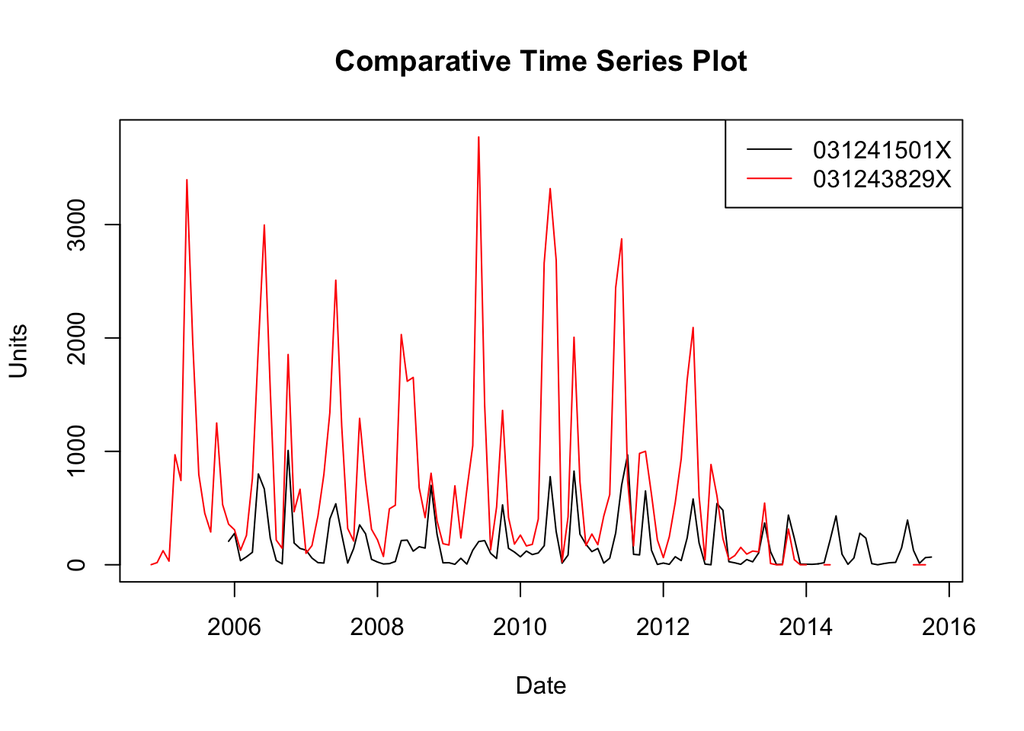

```r
rm(list = ls())
# Get all of the time series and title data
time.series.data = readRDS("time_series.rds")
title.data = readRDS("title_data.rds")
source("Inv_Planning.R")

isbn1 <- "031241501X"
isbn2 <- "031243829X"

plot.two(isbn1, isbn2, time.series.data)
```

## plot.previous.edition <- function(isbn, time.series.data, title.data)

Plots a title and its previous edition as a time series on the same axis.

Usage: * Takes an ISBN as a string and two data frames: title data and title time series as inputs * Plots the time series and the previous edition. If there is no previous edition, it returns an NA.

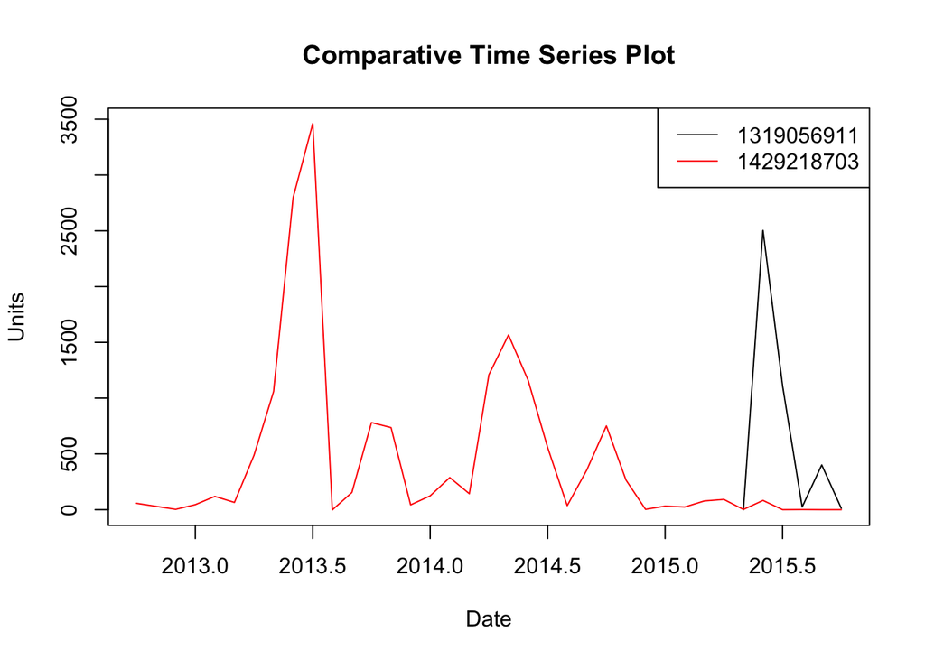

```r
rm(list = ls())
# Get all of the time series and title data
time.series.data = readRDS("time_series.rds")
title.data = readRDS("title_data.rds")
source("Inv_Planning.R")

isbn1 = "1319056911"  # How Life Works
plot.previous.edition(isbn1, time.series.data, title.data)
```

```r
isbn2 = "0312132921"
plot.previous.edition(isbn2, time.series.data, title.data)
```

```
## [1] NA
```

```r
isbn3 <- "031243829X"
plot.previous.edition(isbn3, time.series.data, title.data)
```

```
## [1] NA
```

Time series decomposition with STL (not implemented)

```r
# isbn = "1319056911"  # How Life Works
# isbn.fit = stl(isbn, s.window = "periodic")
# plot(isbn.fit)
```

## forecast.with.previous(isbn, time.series.data, title.data, horizon = 15)

Generates a forecast by adding the previous edition demand to the current edition and forecasting the combination

Usage * Takes an ISBN as a string and two data frames: title series data and title data as inputs * Returns a forecast in a data frame. If there is no previous edition, returns a zero forecast

```r
rm(list = ls())
# Get all of the time series and title data
time.series.data = readRDS("time_series.rds")
title.data = readRDS("title_data.rds")
source("Inv_Planning.R")

isbn = "1319056911"  # How Life Works
isbn.fcst = forecast.with.previous(isbn, time.series.data, title.data, 15)
isbn.fcst
```

```
##              summed
## 2015-11-01 558.5919
## 2015-12-01 558.5919
## 2016-01-01 558.5919
## 2016-02-01 558.5919
## 2016-03-01 558.5919
## 2016-04-01 558.5919
## 2016-05-01 558.5919
## 2016-06-01 558.5919
## 2016-07-01 558.5919
## 2016-08-01 558.5919
## 2016-09-01 558.5919
## 2016-10-01 558.5919
## 2016-11-01 558.5919
## 2016-12-01 558.5919
## 2017-01-01 558.5919
```

```r
isbn3 <- "031243829X"
isbn3.fcst = forecast.with.previous(isbn3, time.series.data, title.data, 15)  # should return 0
isbn3.fcst
```

```
##            zeros
## 2015-11-01     0
## 2015-12-01     0
## 2016-01-01     0
## 2016-02-01     0
## 2016-03-01     0
## 2016-04-01     0
## 2016-05-01     0
## 2016-06-01     0
## 2016-07-01     0
## 2016-08-01     0
## 2016-09-01     0
## 2016-10-01     0
## 2016-11-01     0
## 2016-12-01     0
## 2017-01-01     0
```

## calc.review(forecast, onhand)

Determine if a title should be reviewed for a reprint.

Usage: * Input 2 numeric values: forecast demand and onhand inventory * Output string recommending what action to take

```r
rm(list = ls())
source("Inv_Planning.R")

calc.review(100, 10) # should recommend a review
```

```
## [1] "Print review"
```

```r
calc.review(0, 10) # insuffience information
```

```
## [1] "Insuff data"
```

```r
calc.review(10, 100) # no action
```

```
## [1] "No Review"
```

## create.title.planning.worksheet(title.data, title.forecasts)

Creates a title planning worksheet based on forecasted demand. Recommends a reprint review if forecasted demand exceeds on hand inventory.

Usage: * Input is title data and title forecasts df * Output is a title planning worksheet that is also saved in CSV and RDS formats

```r
rm(list = ls())
# Get all of the time series and title data
title.forecasts = readRDS("forecasts.rds")
title.data = readRDS("title_data.rds")
source("Inv_Planning.R")

title.planning = create.title.planning.worksheet(title.data, title.forecasts)
head(title.planning)
```

```
## Source: local data frame [6 x 18]
##
##                 Author       Isbn           Ean
## 1       REVLIN.RUSSELL 0716756676 9780716756675
## 2   KIRSZNER.LAURIE.G. 1319041086 9781319041083
## 3 HOCKENBURY.SANDRA.E. 1319041957 9781319041953
## 4    FREEDMAN.ROGER.A. 1319042406 9781319042400
## 5    FREEDMAN.ROGER.A. 1319042430 9781319042431
## 6    FREEDMAN.ROGER.A. 1319042465 9781319042462
## Variables not shown: Title (chr), Pub.Date (date), Medium (fctr), Ans.Code
##   (fctr), Available (int), Consignment.On.Hand (int), Reserved.Stock
##   (int), Sets.Made.Up (int), Prev.Edition.Isbn (fctr), Prev.Edition.Ean
##   (fctr), Review (chr), OQ.6 (dbl), OQ.9 (dbl), OQ.12 (dbl), OQ.15 (dbl)
```

## Release Notes

v6 * plot.two function * Eliminate leading blanks in plot.two function * Moved both lines into same panel for easier comparison * align.previous edition * added function align.previous.edition to produce plot * it aligns peaks, not months - this may need to be changed * It probablly also needs an export, or to at least to print the prev isbn in the legend v7 * skipped v8 * sum.previous.edition function created * output.multiple function created